# Exercise 01 - Oliver Zhao - soz63

First we load the relevant libraries and datasets for this assignment:

```r
# Import libraries
library(mosaic)
library(tidyverse)
library(ggplot2)
library(broom)
library(scales)
library(grid)
library(gridExtra)
library(dplyr)

# Import datasets
ABIA = read.csv("~/Github/SDS323_Spring2020/ABIA.csv")
creatinine = read.csv("~/Github/SDS323_Spring2020/creatinine.csv")
Buildings = read.csv("~/Github/SDS323_Spring2020/greenbuildings.csv")
Milk = read.csv("~/Github/SDS323_Spring2020/milk.csv")
```

# Flights at ABIA

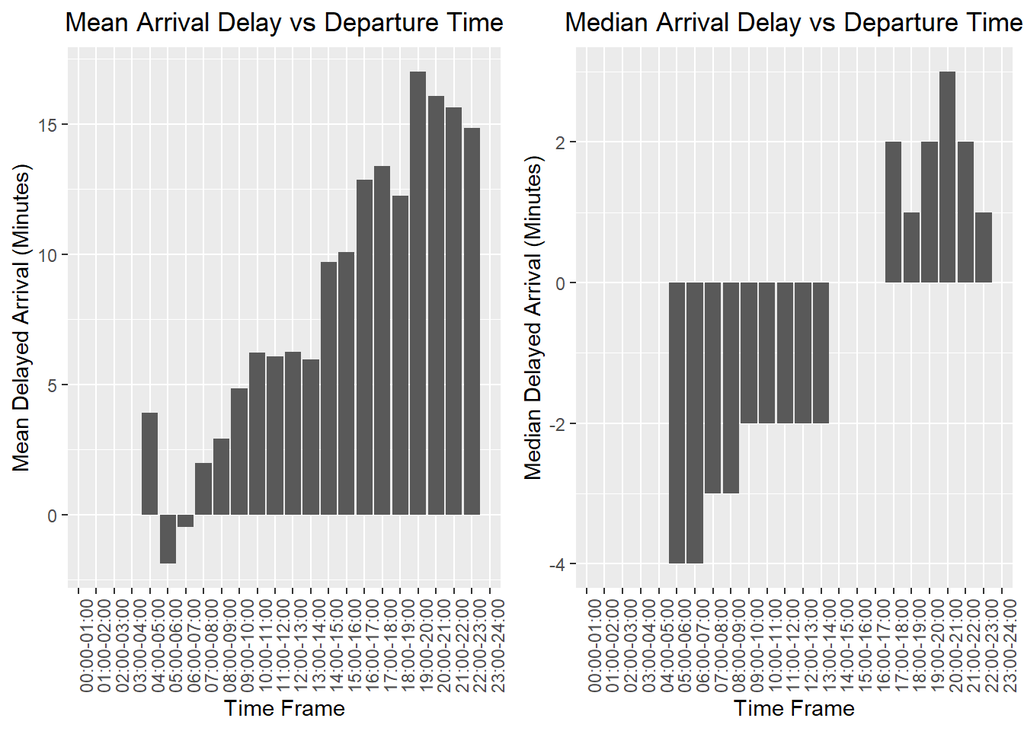

```r
# Calculate median and mean delay in one hour intervals
avgDelay <- matrix(0,24)
medDelay <- matrix(0,24)
for (i in seq(100,2400,100)){
  Temporary <- ABIA[ABIA[,"CRSDepTime"] >= i & ABIA[,"CRSDepTime"] < i+100 & is.na(ABIA[,"CRSDepTime"]) == FALSE,]
  meanDelay <- mean(Temporary[,"ArrDelay"], na.rm = TRUE)
  avgDelay[i/100] <- meanDelay
  medianDelay <- median(Temporary[,"ArrDelay"], na.rm = TRUE)
  medDelay[i/100] <- medianDelay
}

# Calculate median delay by month
monthDelay <- matrix(0,12)
monthDelay1 <- matrix(0,12)
for (i in seq(1,12)){
  Temporary <- ABIA[ABIA[,"Month"] == i & is.na(ABIA[,"Month"]) == FALSE,]
  medianDelay <- median(Temporary[,"ArrDelay"], na.rm = TRUE)
  monthDelay[i] <- medianDelay
  meanDelay <- mean(Temporary[,"ArrDelay"], na.rm = TRUE)
  monthDelay1[i] <- meanDelay
}

# Calculate median delay by day of week
weekDelay <- matrix(0,7)
weekDelay1 <- matrix(0,7)
for (i in seq(1,7)){
  Temporary <- ABIA[ABIA[,"DayOfWeek"] == i & is.na(ABIA[,"DayOfWeek"]) == FALSE,]
  medianDelay <- median(Temporary[,"ArrDelay"], na.rm = TRUE)
  weekDelay[i] <- medianDelay
  meanDelay <- mean(Temporary[,"ArrDelay"], na.rm = TRUE)
  weekDelay1[i] <- meanDelay
}

# Create time labels as strings
TimeFrames <- vector(length = 24)
for (i in seq(1,24)){
  TempLabel <- paste(formatC(i-1, width = 2, flag = "0"),":00-",formatC(i, width = 2, flag = "0"),":00",sep="")
  TimeFrames[i] = TempLabel
}

MonthFrames <- c("January","February","March","April","May","June",
                "July","August","September","October","November","December")
WeekFrames <- c("Monday","Tuesday","Wednesday","Thursday","Friday","Saturday","Sunday")

# Create data frames
HourDelayData <- data.frame(Dep = TimeFrames, AverageDelay = avgDelay, MedianDelay = medDelay)
MonthDelayData <- data.frame(Dep = MonthFrames, AverageDelay = monthDelay1, MedianDelay = monthDelay)
WeekDelayData <- data.frame(Dep = WeekFrames, AverageDelay = weekDelay1, MedianDelay = weekDelay)

# Create bar plot for average delay by time
ggplot(HourDelayData, aes(x=TimeFrames, y=AverageDelay)) +
  geom_bar(stat='identity') +
  theme(axis.text.x = element_text(angle = 90)) +
  labs(title = "Mean Arrival Delay vs Departure Time")+
  theme(plot.title = element_text(hjust = 0.5)) +
  labs(y="Mean Delayed Arrival (Minutes)", x = "Time Frame") -> AvgTime

# Create bar plot for median delay by time
ggplot(HourDelayData, aes(x=TimeFrames, y=MedianDelay)) +
  geom_bar(stat='identity') +
  theme(axis.text.x = element_text(angle = 90)) +
  labs(title = "Median Arrival Delay vs Departure Time")+
  theme(plot.title = element_text(hjust = 0.5)) +
  labs(y="Median Delayed Arrival (Minutes)", x = "Time Frame") -> MedTime

grid.arrange(AvgTime, MedTime, ncol = 2)
```

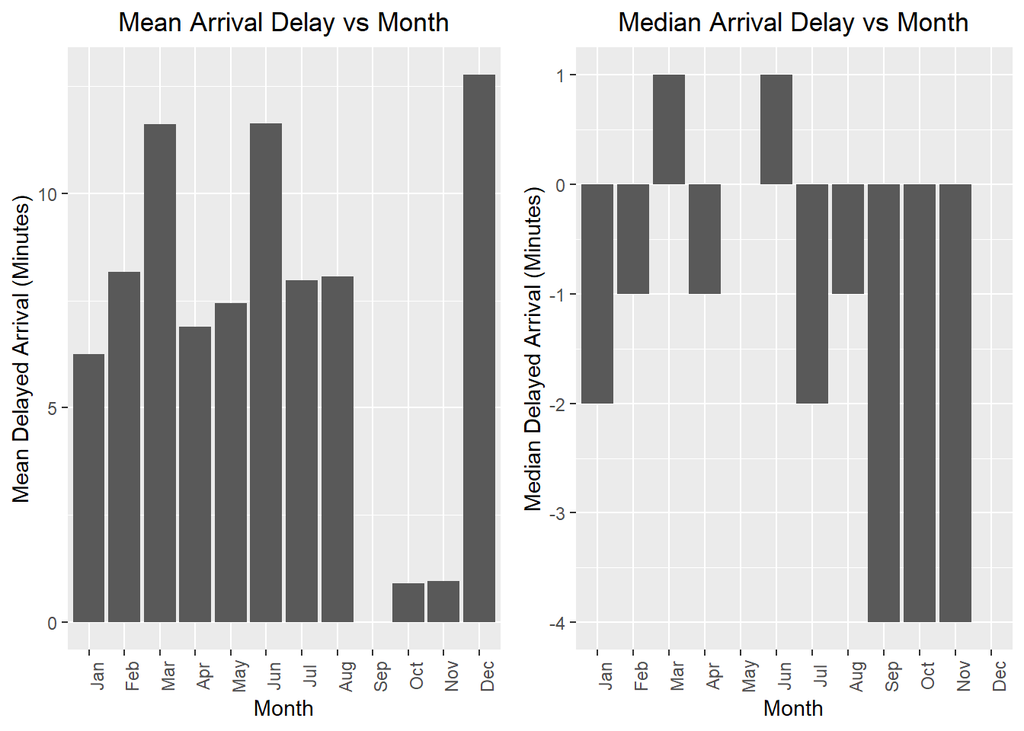

```r
# Create bar plot for average delay by month
ggplot(MonthDelayData, aes(x=month.abb, AverageDelay)) +
  geom_bar(stat='identity') +
  scale_x_discrete(limits = month.abb) +
  theme(axis.text.x = element_text(angle = 90)) +
  labs(title = "Mean Arrival Delay vs Month")+
  theme(plot.title = element_text(hjust = 0.5)) +
  labs(y="Mean Delayed Arrival (Minutes)", x = "Month") -> AvgMonth

# Create bar plot for median delay by month
ggplot(MonthDelayData, aes(x=month.abb, y=MedianDelay)) +
  geom_bar(stat='identity') +
  scale_x_discrete(limits = month.abb) +
  theme(axis.text.x = element_text(angle = 90)) +
  labs(title = "Median Arrival Delay vs Month")+
  theme(plot.title = element_text(hjust = 0.5)) +
  labs(y="Median Delayed Arrival (Minutes)", x = "Month") -> MedMonth

grid.arrange(AvgMonth, MedMonth, ncol = 2)
```

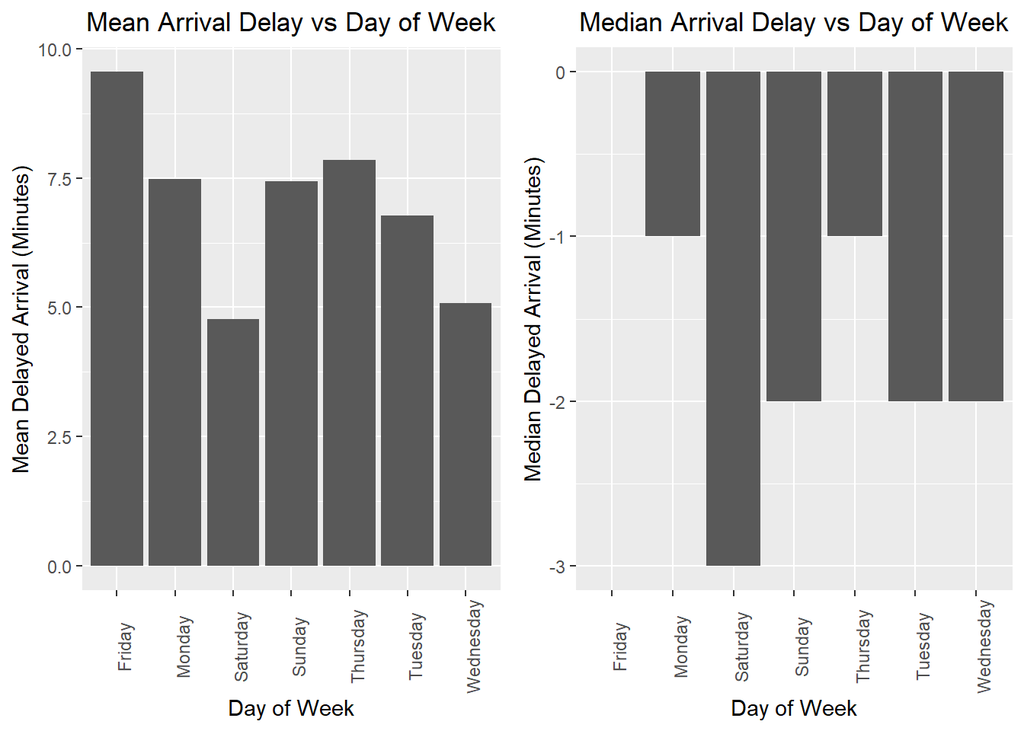

```r
# Create bar plot for average delay by day of week
ggplot(WeekDelayData, aes(x=WeekFrames, y=AverageDelay)) +
  geom_bar(stat='identity') +
  theme(axis.text.x = element_text(angle = 90)) +
  labs(title = "Mean Arrival Delay vs Day of Week")+
  theme(plot.title = element_text(hjust = 0.5)) +
  labs(y="Mean Delayed Arrival (Minutes)", x = "Day of Week") -> AvgWeek

# Create bar plot for median delay by day of week
ggplot(WeekDelayData, aes(x=WeekFrames, y=MedianDelay)) +
  geom_bar(stat='identity') +
  theme(axis.text.x = element_text(angle = 90)) +
  labs(title = "Median Arrival Delay vs Day of Week")+
  theme(plot.title = element_text(hjust = 0.5)) +
  labs(y="Median Delayed Arrival (Minutes)", x = "Day of Week") -> MedWeek

grid.arrange(AvgWeek, MedWeek, ncol = 2)
```

We also see that Saturday provides you the best odds of arriving early, while Friday provides you the worst odds of arriving early. In addition, we see that the Autumn months of September, October, and November, provides you the best odds of arriving early, compared to other months. Although you are more likely to be late than not late in the months of March and June, the median delayed arrival is just a mere minute.

When examining both the average and median arrival delay across time of day, day of week, and month, we can deduct that early arrivals occur more frequently than late arrivals, but the margin of tardiness in late arrivals tend to be more drastic than the margin of earliness in early arrivals. This causes the median arrival times to be usually early, while the mean arrival times are usually late.

# Regression Practice with Creatinine Clearance

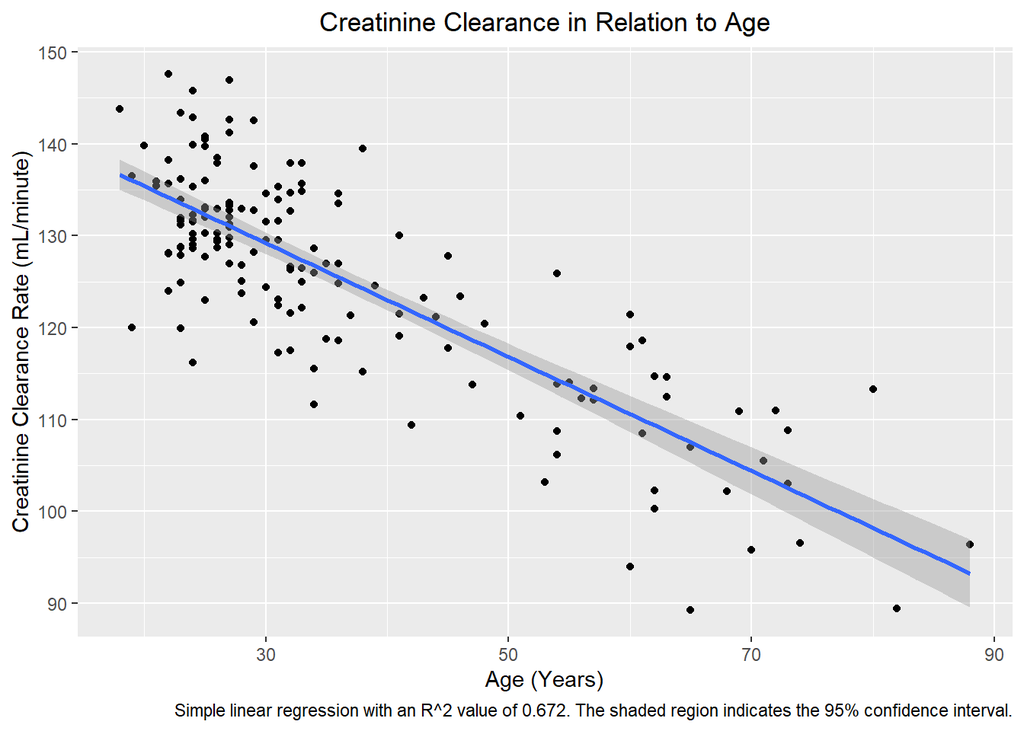

```r
# Read in data
creatinine = read.csv('creatinine.csv')

# Fit linear model for creatine clearance vs age in years
CC = lm(creatclear ~ age, data = creatinine)

# Create simple scatterplot
ggplot(data = creatinine, aes(x=age, y = creatclear)) +
  geom_point() +
  labs(title = "Creatinine Clearance in Relation to Age") +
  theme(plot.title = element_text(hjust = 0.5)) +
  labs(y="Creatinine Clearance Rate (mL/minute)", x = "Age (Years)") +
  geom_smooth(method='lm', formula = y~poly(x,1), se=TRUE, fullrange=FALSE, level=0.95) +
  labs(caption = "Simple linear regression with an R^2 value of 0.672. The shaded region indicates the 95% confidence interval.")
```

```r
# Examine linear regression coefficients
coef(CC)
(Intercept)         age
147.8129158  -0.6198159
summary(CC)$r.squared
[1] 0.6724361
```

Through simple linear regression, we see that the relationship between age and creatinine clearance is:

$$C(A) = -0.6198A + 147.8129$$
Where $C(A)$ is the creatinine clearance as a function of age $A$.

```r
# Predicted creatinine clearance for 40-, 55-, and 60-year old
new_data = data.frame(age = c(40,55,60))
predict(CC, new_data)
```

[output not shown]

In the context of widely accepted medical knowledge however, a normal creatinine clearance is 88-128 mL/min for healthy women and 97-137 mL/min for healthy men. Consequently, even though we do not know the genders for either patients, we can safely say that both patients have sufficient creatinine clearance rates and are arguably equally healthy. This is because having a creatinine clearance rate that is significantly higher than the healthy baseline does not yield any additional health benefits.

# Green Building Problem

## Fact-Checking the Developer Staff’s Initial Claims

Let us quickly fact-check the first claim made by the developer’s staff. The staff claims that “the median market rent in the non-green buildings was $25.00 per square foot per year, while the median market rent in the green buildings was $27.60 per square foot per year: about $2.60 more per square foot” for buildings with at least 10% occupancy. Upon simple analysis of our own data, we see that this is indeed the case

```r
# Fact check claim that median green rent is $27.60 and median non-green rent is $25.00
fact1 <- median(subset(Buildings, green_rating == 1 & leasing_rate >= 10)[,"Rent"], na.rm = TRUE)
fact2 <- median(subset(Buildings, green_rating == 0 & leasing_rate >= 10)[,"Rent"], na.rm = TRUE)
sprintf("The median rent for green buildings, excluding buildings with less than 10 percent occupancy, is: $%.2f",fact1)
[1] "The median rent for green buildings, excluding buildings with less than 10 percent occupancy, is: $27.60"
sprintf("The median rent for non-green buildings, excluding buildings with less than 10 percent occupancy, is: $%.2f",fact2)
[1] "The median rent for non-green buildings, excluding buildings with less than 10 percent occupancy, is: $25.03"
```

## Examining Rental Price per Sq. Ft. as a Function of Building Size

This analysis however, does not take into account of the square footage of the buildings. Below, we implement Loess regression to visually examine whether building size measured in square footage affects the rental price per square foot. We see that indeed, at the extremes of the range from 0 to 500,000 square feet, the rental price seems to noticeably change.

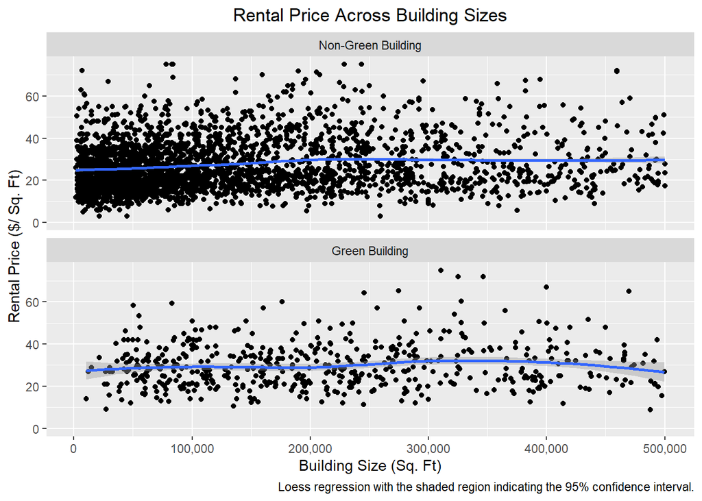

```r
# Compare median rent price with building size
green_names <- c(
  "0" = "Non-Green Building",
  "1" = "Green Building"
)
ggplot(data = subset(Buildings, size <= 500000), aes(x=size, y=Rent)) +
  geom_point() +
  geom_smooth(method = "loess") +
  facet_wrap(~ green_rating, nrow = 2, labeller = labeller(green_rating = green_names)) +
  labs(title = "Rental Price Across Building Sizes")+
  theme(plot.title = element_text(hjust = 0.5)) +
  labs(y= "Rental Price ($/ Sq. Ft)", x = "Building Size (Sq. Ft)") +
  scale_x_continuous(labels = comma) +
  ylim(0, 75) +
  labs(caption = "Loess regression with the shaded region indicating the 95% confidence interval.")
```

## Reevaluating the Median Rental Price for Green and Non-Green Buildings

While the staff’s claim is correct, it makes more sense to examine the median market rent for buildings with similar square footages. Because we know that the building to be built will be about 250,000 square feet, it is worth checking to see whether the median rent shall change according to building size. Consequently, let us analyze the median rent for green and non-green buildings for buildings that have a square footage of 150,000-350,000.

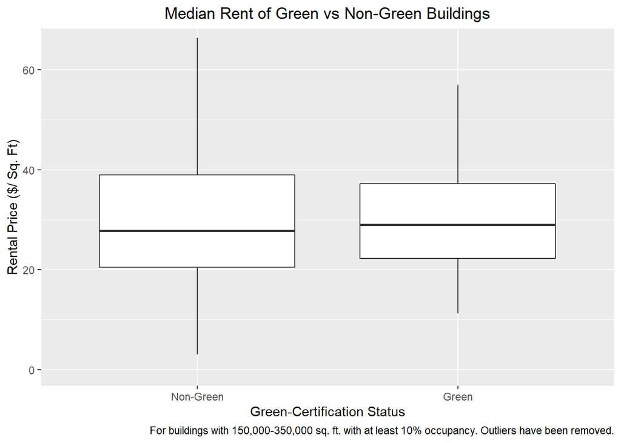

```r
# Isolate buildings that are 150,000 to 350,000 square feet to examine median rent of green vs non-green
# We see that for our building size range, the median green rent is $29.00 and non-green rent is $27.79 (smaller margin)
SizeSubset <- subset(Buildings, size >=150000 & size <= 350000 & leasing_rate >= 10)
GreenSizeSubset <- subset(SizeSubset, green_rating == 1)
NormSizeSubset <- subset(SizeSubset, green_rating == 0)
MedGreenRent <- median(GreenSizeSubset[,"Rent"], na.rm = TRUE)
MedNormRent <- median(NormSizeSubset[,"Rent"], na.rm = TRUE)
sprintf("The median rent for green buildings that are 150,000-350,000 sq ft, excluding buildings with less than 10 percent occupancy, is: $%.2f",MedGreenRent)
[1] "The median rent for green buildings that are 150,000-350,000 sq ft, excluding buildings with less than 10 percent occupancy, is: $29.00"
sprintf("The median rent for non-green buildings that are 150,000-350,000 sq ft, excluding buildings with less than 10 percent occupancy, is: $%.2f",MedNormRent)
[1] "The median rent for non-green buildings that are 150,000-350,000 sq ft, excluding buildings with less than 10 percent occupancy, is: $27.79"

RentSum = SizeSubset %>%
  group_by(green_rating)  %>%  # group the data points by model name
  summarize(Rent.mean = mean(Rent))  # calculate a mean for each model

# still not in order...
ggplot(SizeSubset, aes(x=factor(green_rating), y=Rent)) +
  geom_boxplot(outlier.shape=NA) +
  coord_cartesian(ylim = c(0,65)) +
  labs(title = "Median Rent of Green vs Non-Green Buildings")+
  theme(plot.title = element_text(hjust = 0.5)) +
  labs(y= "Rental Price ($/ Sq. Ft)", x = "Green-Certification Status") +
  scale_x_discrete(breaks=c(0,1),labels=c("Non-Green","Green")) +
  labs(caption = "For buildings with 150,000-350,000 sq. ft. with at least 10% occupancy. Outliers have been removed.")
```

## Examining How Building Class (Quality) Affects Rental Price Estimates

Luckily, our dataset also describes the “quality” of the buildings, which can provide us some deeper insights on the rental price differences across different levels of quality in green and non-green buildings. If we calculate the median prices by the building quality and green-certification status, we gain some interesting additional insights.

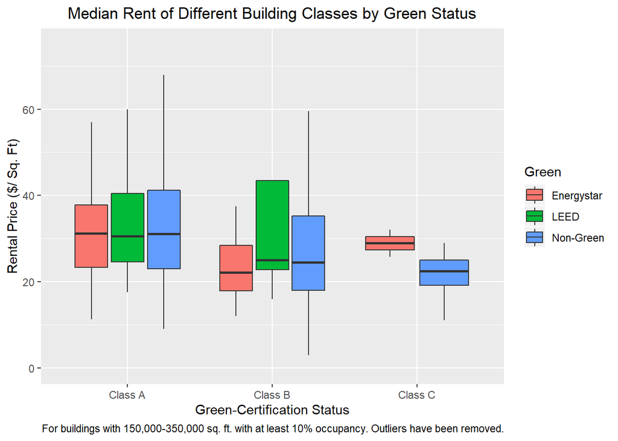

```r
# Add single attribute for building classes A, B, and C
SizeSubset <- SizeSubset %>% mutate(
     Class = case_when(
         class_a==1 ~ "A",
         class_b==1 ~ "B",
         TRUE ~ "C"
     )
)

# Add single attribute for building green certification status
SizeSubset <- SizeSubset %>% mutate(
     Green = case_when(
         LEED==1 ~ "LEED",
         Energystar==1 ~ "Energystar",
         TRUE ~ "Non-Green"
     )
)

ggplot(SizeSubset, aes(x=factor(Class), y=Rent, fill = Green)) +
  geom_boxplot(outlier.shape=NA) +
  coord_cartesian(ylim = c(0,75)) +
  labs(title = "Median Rent of Different Building Classes by Green Status")+
  theme(plot.title = element_text(hjust = 0.5)) +
  labs(y= "Rental Price ($/ Sq. Ft)", x = "Green-Certification Status") +
  scale_x_discrete(labels=c("Class A","Class B","Class C")) +
  labs(caption = "For buildings with 150,000-350,000 sq. ft. with at least 10% occupancy. Outliers have been removed.")
```

## Qualitatively Examining How Building Age Affects Rental Prices

Perhaps the last factor we should take into consideration is the age of buildings, and how it affects the rental prices. First however, let us examine the age distribution of the green and non-green buildings, as shown below. The density map clearly shows that the green buildings are generally newer than the non-green buildings. This will be important to note in the next figure.

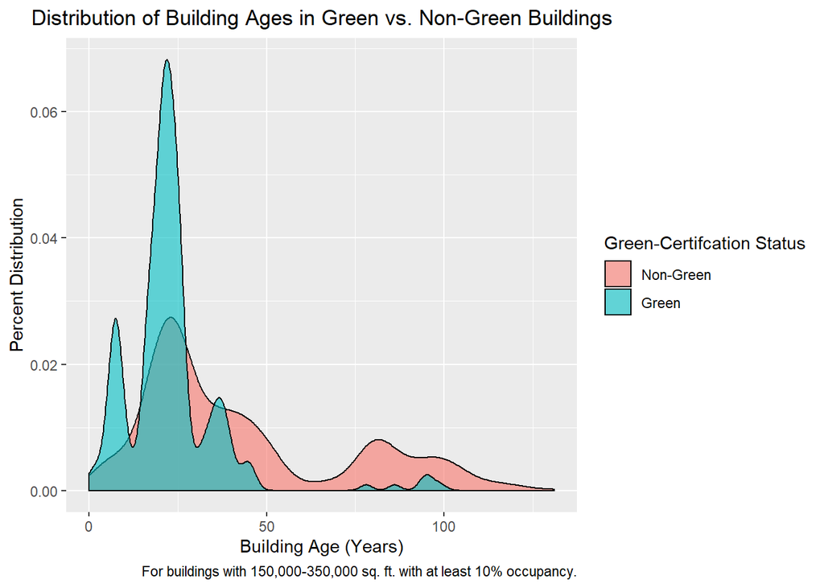

```r
ggplot(SizeSubset, aes(x=age)) +
  geom_density(aes(fill=factor(green_rating)),alpha=0.6) +
  labs(title = "Distribution of Building Ages in Green vs. Non-Green Buildings") +
  labs(y = "Percent Distribution", x = "Building Age (Years)") +
  theme(plot.title = element_text(hjust = 0.5)) +
  scale_fill_discrete(name='Green-Certifcation Status',labels=c("Non-Green", "Green")) +
  labs(caption = "For buildings with 150,000-350,000 sq. ft. with at least 10% occupancy.")
```

Let us examine how the building age average the average rental price among buildings that have a square footage of 150,000-350,000 square feet. We see that in both green and non-green buildings, there is on average, a decreasing trend in which rent becomes lower as the building ages. Recall that the age distribution of the green buildings tends to be younger than that of the non-green buildings.

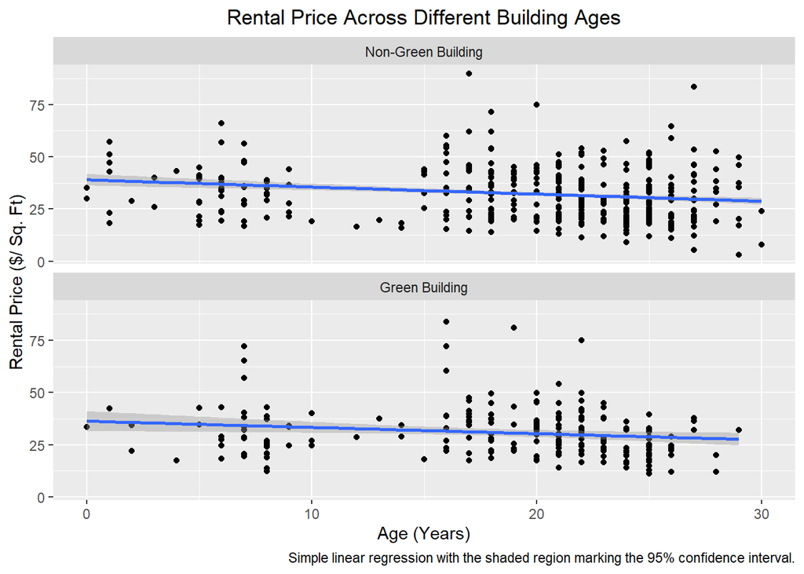

```r
## Compare median rent price with age of building (30 years or less)
ggplot(data = subset(SizeSubset, age <= 30), aes(x=age, y=Rent)) +
  geom_point() +
  geom_smooth(method='lm', formula = y~poly(x,1), se=TRUE, fullrange=FALSE, level=0.95) +
  facet_wrap(~ green_rating, nrow = 2, labeller = labeller(green_rating = green_names)) +
  labs(title = "Rental Price Across Different Building Ages")+
  theme(plot.title = element_text(hjust = 0.5)) +
  labs(y= "Rental Price ($/ Sq. Ft)", x = "Age (Years)") +
  labs(caption ="Simple linear regression with the shaded region marking the 95% confidence interval.")
```

When these two pieces of information are taken into consideration together, it is worth noting that the difference between rental prices in green and non-green buildings may be partially due to the fact that green buildings tend to be newer than non-green buildings, resulting in a boost in the median rental price of green buildings, since newer buildings tend to have higher rental values.

The reason why we do not try to explicitly quantify how much additional profit this age factor generates, is because linear regression predicts an average rental price based on age, rather than a median rental price. Since the median rental price is what we have been working with - due to its robustness against outliers - it would be difficult to gauge the value in predicting average rental price based on age. However, it is still important to at least acknowledge this possible underlying trend.

## Reevalutating Developer Staff’s Claims on Opportunity-Cost of Building a Green Building

Now let us evaluate the benefits of building a green building instead of a non-green building, on the premise that it will be 250,000 square feet, Energystar-certified rather than LEED-certified, and belonging to Class C in terms of building quality. We see that the difference in the median rental price gives us an additional $6.40 per square footage in the green building. Given that the median occupancy of a Energystar-certified, Class C, 150,000-350,000 square foot building is 90.67%, we expect to rent out about 226,675 square feet of the building. In addition, it is worth noting that the median occupancy of a non-green, Class C, 150,000-350,000 square foot building is 84.33%, significantly lower than that of its Energystar-certified equivalent. Both these differences in median rental price per square foot and the leasing occupancy rates, should be taken into consideration when calculating the cost-benefit ratio of a Energystar-certified vs non-green building.

Consequently, a Energystar-certified building would acquire about $6,550,908 in annual revenue and a non-green builidng would net about $4,743,563 in annual revenue, with a net difference of $1,807,345. Given that the additional cost of making a building Energystar-certified is $5,000,000, it would take just 2.77 years. In general, the total cost of the entire building will be recuperated in 16.03 years, in contrast to a non-green building that would take 21.08 years to recuperate entire building costs.

```r
median(subset(SizeSubset, Energystar == 1 & size >=150000 & size <= 350000 & class_a == 0 & class_b == 0)[,"leasing_rate"], na.rm = TRUE)
[1] 90.67
median(subset(SizeSubset, green_rating == 0 & size >=150000 & size <= 350000 & class_a == 0 & class_b == 0)[,"leasing_rate"], na.rm = TRUE)
[1] 84.33
250000*0.9067 # how much square feet will be rented out
[1] 226675
#226675*6.40 # total revenue in rented out space
5000000/1807345 # how long to recuperate additional costs for green-certification
[1] 2.766489
28.9*226675 # annual revenue for green
[1] 6550908
22.5*210825 # annual revenue for non-green
[1] 4743563
28.9*226675-22.5*210825 # difference in annual revenue
[1] 1807345
105000000/(28.9*226675) # number of years to pay off green building
[1] 16.02831
100000000/(22.5*210825) # number of years to pay off non-green building
[1] 21.0812
```

## Final Conclusion: Build a Green Building Under Certain Constraints

The final conclusion is that under the right circumstances, building a green building can be massively profitable, resulting in a faster recuperate speed, as well as an increase in revenue every year. However, as shown in earlier figures, this is only under the following assumptions:

- While it was mentioned that it costs an additional $5,000,000 to make a building green, it did not specify the cost of making it Energystar-certified or LEED-certified in particular. In our analysis, we presume the costs for either are the same.
- The new building shall be built as Class C.
- The new building shall have a square footage of 250,000 square feet.

If any of these three conditions are not met, the conclusion may change and re-analysis will be necessary to examine whether the building will be more profitable when being green-certified. The analysis was made on the presumption that the building developers want to figure out how to gather the largest benefits of going green as a first priority. If this presumption is not true, this analysis may be moot, such as the example case in which the building developer is not interested in building a Class C building.

# Milk Prices Problem

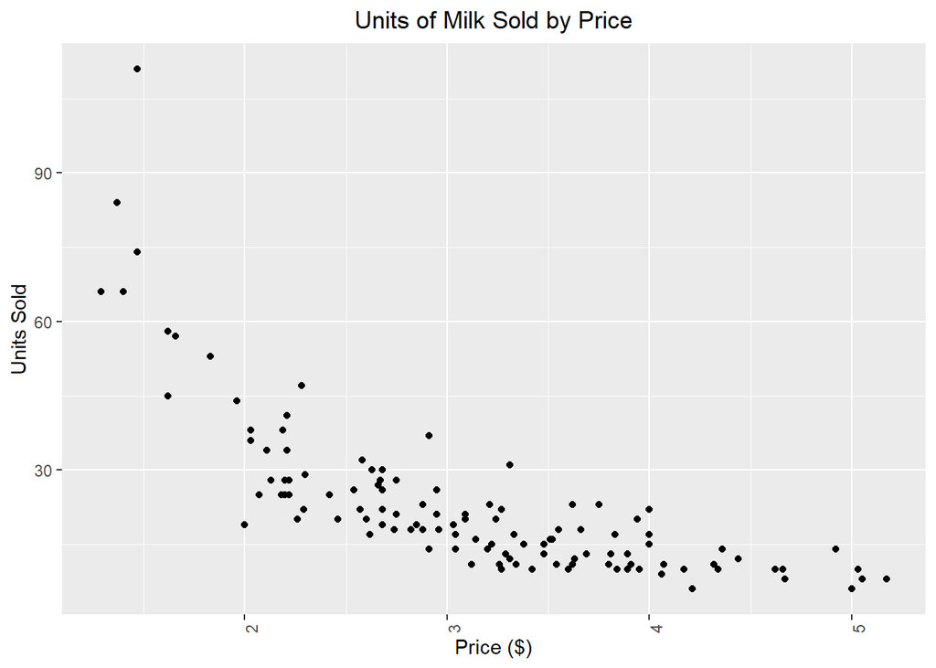

```r
# Create scatterplot plot for milk prices and units sold
ggplot(Milk, aes(x=price, y=sales)) +
  geom_point() +
  theme(axis.text.x = element_text(angle = 90)) +
  labs(title = "Units of Milk Sold by Price")+
  theme(plot.title = element_text(hjust = 0.5)) +
  labs(y= "Units Sold", x = "Price ($)")
```

## Part 1: Expressing Net Profit as an Equation

The net profit $N$ defined as the revenue subtracted by the costs. Let us use $C = 1$ to denote that the wholesale cost of purchasing a unit of milk is $1, $P$ to denote the retail price, $Q$ to denote the quantity sold, and $N$ as the net profit. The costs of acquiring the milk is simply $CQ$, while the revenue from selling the milk - assuming all is sold - is just $PQ$. Consequently, the net profit is

$$N = Q(P-C).$$

## Part 2: Modeling the Demand Curve of Milk

In economic models, the demand curves are usually modeled with a power function, where the general form is
$$y = e^\alpha x^\beta$$
Where $\alpha$ and $\beta$ are fitted constants and $x$ is the dependant variable, which in our case is the price $Q$. By using some simple transformations, as shown below, we can fit this equation through linear regression
$$\begin{equation}
\begin{split}
Q & =e^\alpha P^\beta\\
log(Q) & = \alpha + \beta log(P)
\end{split}
\end{equation}$$
Now let us fit this data through simple linear regression

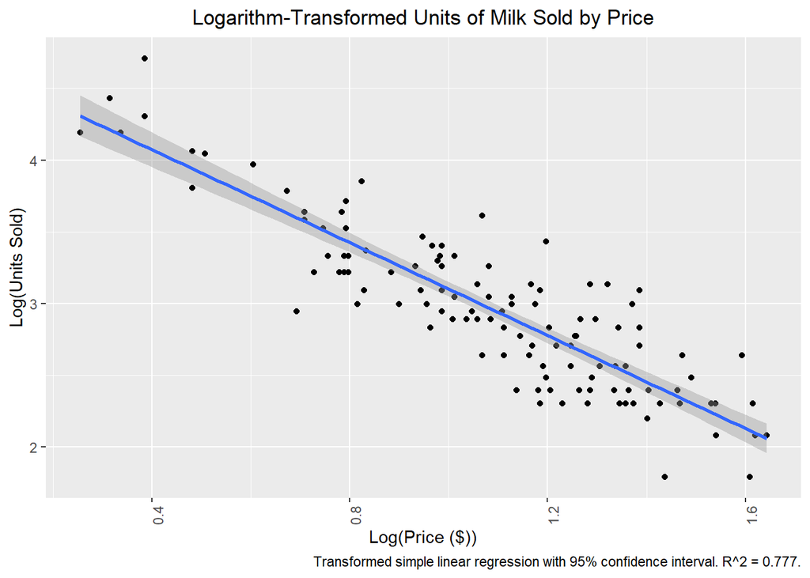

```r
# Create transformed scatterplot plot for milk prices and units sold
ggplot(Milk, aes(x=log(price), y=log(sales))) +
  geom_point() +
  geom_smooth(method='lm',formula = y~poly(x,1), se=TRUE, fullrange=FALSE, level=0.95) +
  theme(axis.text.x = element_text(angle = 90)) +
  labs(title = "Logarithm-Transformed Units of Milk Sold by Price")+
  theme(plot.title = element_text(hjust = 0.5)) +
  labs(y= "Log(Units Sold)", x = "Log(Price ($))") +
  labs(caption = "Transformed simple linear regression with 95% confidence interval. R^2 = 0.777.")
```

```r
# Isolate coefficients from quadratic regression
MilkModel <- lm(log(sales) ~ log(price), data = Milk)
MilkCoef <- coef(MilkModel)
summary(MilkModel)$r.squared
[1] 0.7772187
```

Hence, we see that the fitted equation has a $R^2$ value of about 0.777 and the fitted equation is expressed as
$$\begin{equation}
\begin{split}
log(Q) & = 4.721 -1.619 \ log(P)\\
\alpha & = 4.721 \\
\beta & = -1.618
\end{split}
\end{equation}$$
Consequently, our power function model is
$$Q = e^{4.721}P^{-1.618}$$

## Part 3: Expressing Net Profit as a Function of Retail Price and Wholesale Price Only

If we want to isolate the net profit $N$ as a function of $P$ and $C$ only, we simply substitute and get $$
$$\begin{equation}
\begin{split}
N & = Q(P-C)\\
N & = e^{4.721}P^{-1.618}(P-C)
\end{split}
\end{equation}$$

## Part 4: Maximizing Net Profit

Although graphing is not strictly required, it is helpful to visually examine the relationship between net profit $N$ and the retail price $P$. In this graph, we assume that $C=1$, or that the wholesale cost per unit of milk is $1.00.

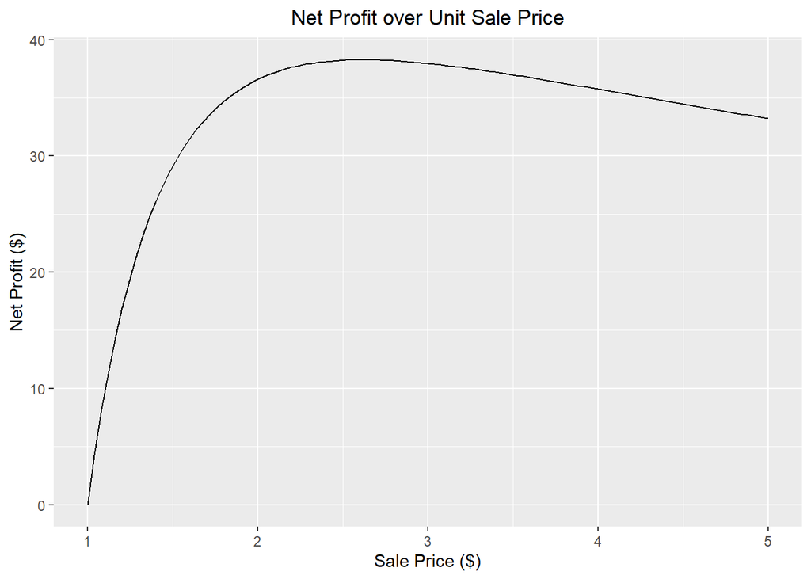

```r
Profit = function(x) exp(4.721)*(x**(-1.618))*(x-1)
ggplot(data = data.frame(x = 0), mapping = aes(x = x)) +
  stat_function(fun = Profit) + xlim(1,5) +
  labs(title = "Net Profit over Unit Sale Price") +
  theme(plot.title = element_text(hjust = 0.5)) +
  labs(y= "Net Profit ($)", x = "Sale Price ($)")
```

```r
optimize(Profit, interval=c(1, 5), maximum=TRUE)
$maximum
[1] 2.618121

$objective
[1] 38.28317
```

By viewing the global maximum of that point, we easily see that we can maximze our profit by charging a retail price of about $2.62 per unit of milk, resulting in a maximum profit of about $38.28.